# Problem Set #1

ECON 329

Colin Pi

## 1.

```r
avg_2007 <- CountryLevelData %>% filter(year == 2007) %>% group_by(continent) %>% summarize(average = mean(pop*gdpPercap, na.rm = TRUE))
knitr::kable(avg_2007)
```

| continent | average |
| --- | --- |
| Africa | 45778570846 |
| Americas | 776723426068 |
| Asia | 627513635079 |
| Europe | 493183311052 |
| Oceania | 403657044512 |

## 2.

*H*<sub>0</sub>: the averages of GDP in Europe and America are equal ($\mu$<sub>Europe</sub> = $\mu$<sub>America</sub>)

*H*<sub>1</sub>: the averages of GDP in Europe and America are not equal ($\mu$<sub>Europe</sub> $\neq$ $\mu$<sub>America</sub>)

### 1957

```r
data_1957 <- CountryLevelData %>% mutate(totalGdp = gdpPercap*pop) %>% filter(year == 1957 & continent %in% c("Europe","Americas"))
test1 <- t.test(totalGdp ~ continent, data = data_1957)
test1
```

```
##
##  Welch Two Sample t-test
##
## data:  totalGdp by continent
## t = 0.29111, df = 28.555, p-value = 0.7731
## alternative hypothesis: true difference in means is not equal to 0
## 95 percent confidence interval:
##  -185901300784  247556413032
## sample estimates:
## mean in group Americas   mean in group Europe
##           140817061264           109989505140
```

Based on the two samples t-test, we can see that there is not a significant evidence to reject the null hypothesis that the averages of GDP of both continents are the same in 1957 (p-value = 0.7731).

### 2007

```r
data_2007 <- CountryLevelData %>% mutate(totalGdp = gdpPercap*pop) %>% filter(year == 2007 & continent %in% c("Europe","Americas"))
test2 <- t.test(totalGdp ~ continent, data = data_2007)
test2
```

```
##
##  Welch Two Sample t-test
##
## data:  totalGdp by continent
## t = 0.53565, df = 26.78, p-value = 0.5966
## alternative hypothesis: true difference in means is not equal to 0
## 95 percent confidence interval:
##  -802985671100 1370065901133
## sample estimates:
## mean in group Americas   mean in group Europe
##           776723426068           493183311052
```

Based on the two samples t-test, we can see that there is not a significant evidence to reject the null hypothesis that the averages of GDP of both continents are the same in 2007 (p-value = 0.5966)

## 3.

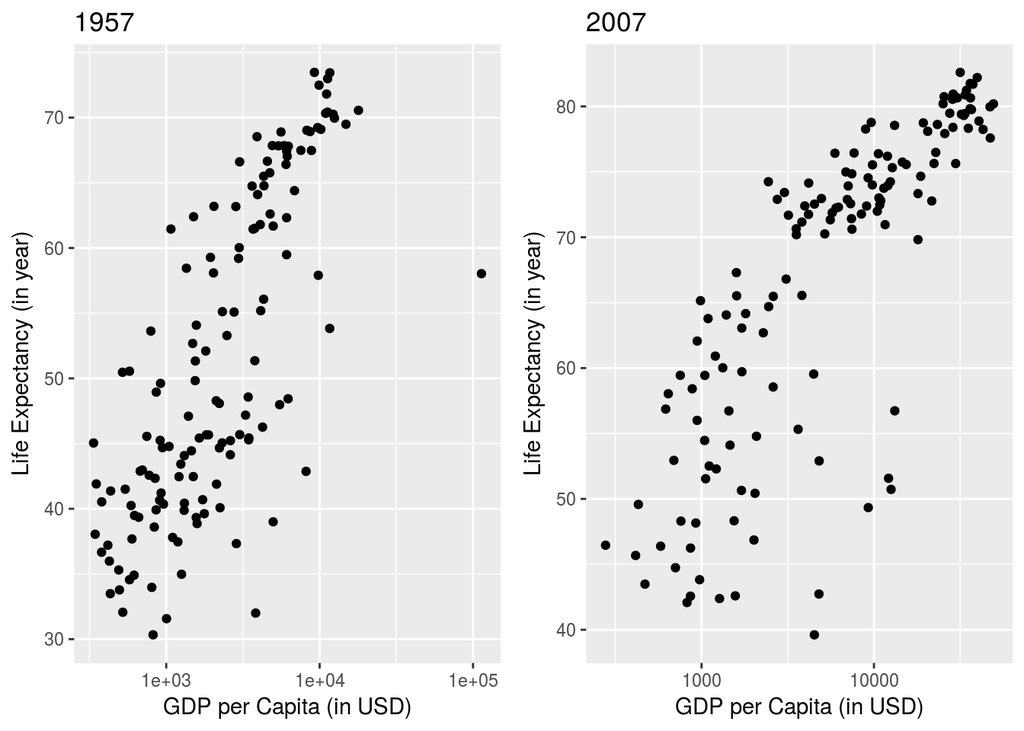

```r
data_1957_all <- CountryLevelData %>% filter(year == 1957)
plot1 <- ggplot(data = data_1957_all) +
  geom_point(aes(x = gdpPercap, y = lifeExp)) +
  scale_x_log10() +
  labs(title="1957",x="GDP per Capita (in USD)",y="Life Expectancy (in year)")

data_2007_all <- CountryLevelData %>% filter(year == 2007)
plot2 <- ggplot(data = data_2007_all) +
  geom_point(aes(x = gdpPercap, y = lifeExp)) +
  scale_x_log10() +
  labs(title="2007",x="GDP per Capita (in USD)",y="Life Expectancy (in year)")

grid.arrange(plot1, plot2, ncol=2)
```

## 4.

```r
avg_2002 <- CountryLevelData %>% filter(year == 2002) %>% group_by(continent) %>% summarize(TotalPop = sum(as.numeric(pop), na.rm = TRUE), TotalGDP = sum(gdpPercap*as.numeric(pop), na.rm = TRUE)) %>% mutate(gdpPercap = TotalGDP / TotalPop)
knitr::kable(avg_2002)
```

| continent | TotalPop | TotalGDP | gdpPercap |
| --- | --- | --- | --- |
| Africa | 833723916 | 1.835783e+12 | 2201.907 |
| Americas | 849772762 | 1.653122e+13 | 19453.690 |
| Asia | 3601802203 | 1.511540e+13 | 4196.621 |
| Europe | 578223869 | 1.309346e+13 | 22644.282 |
| Oceania | 23454829 | 6.904738e+11 | 29438.448 |

## 5.

*H*<sub>0</sub>: the coin is fair (Pr = .5)

*H*<sub>1</sub>: the coin is not fair (Pr $\neq$ .5)

```r
flips = 100
heads = 65
p0 = .5

coin <- binom.test(heads, flips, p0)
coin
```

```
##
##  Exact binomial test
##
## data:  heads and flips
## number of successes = 65, number of trials = 100, p-value =
## 0.003518
## alternative hypothesis: true probability of success is not equal to 0.5
## 95 percent confidence interval:
##  0.5481506 0.7427062
## sample estimates:
## probability of success
##                   0.65
```

Based on the exact binomial test, we can see that there is a significant evidence to reject the null hypothesis that coin is fair (p-value = 0.0035176).

## 6.

*H*<sub>0</sub>: the dice is fair (Pr of each number’s coming out = 1/6)

*H*<sub>1</sub>: the dice is not fair (Pr of each number’s coming out $\neq$ 1/6)

```r
obs <- c(19,32,36,26,42,25)
dice <- chisq.test(obs)
dice
```

```
##
##  Chi-squared test for given probabilities
##
## data:  obs
## X-squared = 11.533, df = 5, p-value = 0.04177
```

## 7.

```r
n <- 80
sampleMean <- 44500
populationMean <- 50000
std <- 10500
t_stat <- (sampleMean - populationMean)/(std/sqrt(n))
p_value <- 2*pt(-abs(t_stat),df=n-1)
```

*H*<sub>0</sub>: the sample mean of the income in Northfield equals to population mean ($\bar{X}$<sub>Northfield</sub> = $\mu$<sub>Northfield</sub>)

*H*<sub>1</sub>: the sample mean of the income in Northfield does not equal to population mean ($\bar{X}$<sub>Northfield</sub> $\neq$ $\mu$<sub>Northfield</sub>)

One sample t-test result shows that there exists a significant evidence to reject the null hypothesis that sample mean equals to population mean (p-value = 1.147e-05).

## 8.

```r
error <- qt(0.995,df=n-1)*std/sqrt(n)
lowerBound <- sampleMean - error
upperBound <- sampleMean + error
```

## 9.

```r
t_stat2 <- qt(0.025, df = n-1)
std2 <- (sampleMean - populationMean)/t_stat2*sqrt(n)
```

The smallest sample standard deviation is 24714.758.